# Revision

444 Lecture 27

Brian Weatherson

2024-04-23

5. Describe an example where Sen’s Condition L (Liberalism) and Condition P (Pareto) conflict.

## From Last Time

1. Briefly describe the difference between what Lackey calls “inflationary” and “deflationary” accounts of group belief, and give an example of each.
2. Explain the Conditionalisation constraint in Russell, Hawthorne and Buchak’s paper *Groupthink*.
3. In a local election, with 100 voters, the voters have the following preferences. 45 people rank the candidates ADBC (i.e., A first, D second, B third, C fourth); 25 rank them BCDA; 20 rank them DABC; 10 rank them CDBA. Who would win if the voters vote sincerely, and the city uses first-past-the-post voting? Who would win if the voters vote sincerely, and the city uses ranked choice (i.e., alternate vote) voting? Very briefly (in a couple of sentences), which verdict do you think better reflects the will of the voters?

## Still Last Time

4. State Arrow’s **Independence of Irrelevant Alternatives** condition.

## Sen

5. Describe an example where Sen’s Condition L (Liberalism) and Condition P (Pareto) conflict.

## Sen

A and B each have the following preferences about bedroom color.

- The best outcome is that their bedroom is pink, and the other person’s is blue.
- The second best outcome is that both bedrooms are blue.
- The third best outcome is that both bedrooms are pink.
- The worst outcome is that their bedroom is blue, and the other bedroom is pink.

Each person prefers having a pink bedroom to a blue bedroom, holding fixed what the other person does. So if L says that people choose their own bedroom color, that means they’ll choose pink. But that means we’ll end up with the third best outcome; they would both prefer a world where both bedrooms are blue.

6. Consider an Axelrod-style Prisoners Dilemma tournament with just the following three strategies: Tit-for-Tat (i.e., C at move one, then do whatever the other person did last time); Grim Trigger (i.e., C until the other person plays D, then D forever); and a strategy that plays D until the other person plays D, then C forever. Each will play 100 rounds against the other two. The payoffs each round are (as normal), 5 points for playing D against C, 3 points for playing C against C, 1 point for playing D against D, 0 points for playing C against D. How many points over the 200 games (i.e., 100 rounds against 2 opponents) will each of them end up with?

Call the strategies TFT, GT, and Test.

Final scores: TFT 597, GT 791, Test 303.

7. Describe an example of a **focal point** in Schelling’s sense.

A coordination game is a game where the highest priority of each player is to do what the other(s) do, i.e., to coordinate. A focal point of a game like this is a solution that jumps out at people as being one that others will naturally latch on to. For example, if a group knew just that we were all in Chicago, and wanted to meet up, heading to the Bean would make sense; it’s a focal point meaning that it’s a solution to a problem like this that people will naturally gravitate towards, and do so in the (rational) belief that others will do so too.

8. What is the difference between weak dominance and strict dominance? Describe an example where the two notions come apart.

Option A strictly dominates B if it has a higher return whatever the other player does.

Option A weakly dominates B if it never has a lower return than B, and sometimes has a higher return.

## Sen

Each person prefers having a pink bedroom to a blue bedroom, holding fixed what the other person does. So if L says that people choose their own bedroom color, that means they’ll choose pink. But that means we’ll end up with the third best outcome; they would both prefer a world where both bedrooms are blue.

## Sen

The trick here is making sure **everyone** prefers the illiberal outcome to the liberal one.

This isn’t always easy, since the person who makes the choice still has to prefer something else even though they made a choice.

## Axelrod - Q6

Consider an Axelrod-style Prisoners Dilemma tournament with just the following three strategies:

1. Tit-for-Tat (i.e., C at move one, then do whatever the other person did last time);
2. Grim Trigger (i.e., C until the other person plays D, then D forever); and
3. A strategy that plays D until the other person plays D, then C forever. Each will play 100 rounds against the other two.

## Q6

The payoffs each round are (as normal), 5 points for playing D against C, 3 points for playing C against C, 1 point for playing D against D, 0 points for playing C against D. So it’s like this table

|  | C | D |
| --- | --- | --- |
| **C** | 3,3 | 0,5 |
| **D** | 5,0 | 1,1 |

How many points over the 200 games (i.e., 100 rounds against 2 opponents) will each of them end up with?

## Q6

Call the strategies TFT, GT, and Test.

## TFT vs GT

Both get 300 points, since it’s all C all the way.

## TFT vs Test

Round 1, TFT plays C, Test plays D, so it’s 0-5.

Round 2, TFT plays D, Test plays D, so it’s 1-1.

Round 3, TFT plays D, Test plays C, so it’s 5-0.

So far the score is 6-6.

After that they play C every round, so it ends up 297-297.

## GT vs Test

Round 1, GT plays C, Test plays D, so it’s 0-5.

Round 2, GT plays D, Test plays D, so it’s 1-1.

So GT gets 491 points, and Test gets 6 points.

## Final Answer

Final scores: TFT 597, GT 791, Test 303.

## Focal Point

7. Describe an example of a **focal point** in Schelling’s sense.

A coordination game is a game where the highest priority of each player is to do what the other(s) do, i.e., to coordinate.

A focal point of a game like this is a solution that jumps out at people as being one that others will naturally latch on to.

For example, if a group knew just that we were all in Chicago, and wanted to meet up, heading to the Bean would make sense; it’s a focal point meaning that it’s a solution to a problem like this that people will naturally gravitate towards, and do so in the (rational) belief that others will do so too.

## Dominance

What is the difference between weak dominance and strict dominance? Describe an example where the two notions come apart.

## Q8

Option A strictly dominates B if it has a higher return whatever the other player does.

Option A weakly dominates B if it never has a lower return than B, and sometimes has a higher return.

## Q8

In the game below, Up weakly, but not strongly, dominates Down.

|  | Left | Right |
| --- | --- | --- |
| Up | 1,1 | 1,0 |
| Down | 0,0 | 1,1 |

9. In Table 1, what will be the result if both players use iterated deletion of strictly dominated strategies to decide what to do? (In each cell, Row’s payouts are first, and Column’s are second.)

## Iterated Deletion

In Table 1, what will be the result if both players use iterated deletion of strictly dominated strategies to decide what to do? (In each cell, Row’s payouts are first, and Column’s are second.)

|  | L | C | R |
| --- | --- | --- | --- |
| U | 1,1 | 2,0 | 2,2 |
| M | 0,3 | 1,5 | 4,4 |
| D | 2,4 | 3,6 | 3,0 |

Table 1: Game table for Q9

D strictly dominates U, resulting in Table 2.

## Q9

D strictly dominates U, resulting in Table 2.

|  | L | C | R |
| --- | --- | --- | --- |
| M | 0,3 | 1,5 | 4,4 |
| D | 2,4 | 3,6 | 3,0 |

Table 2: After deleting U

After that, C strictly dominates L and R, resulting in Table 3.

## Q9

After that, C strictly dominates L and R, resulting in Table 3.

|  | C |
| --- | --- |
| M | 1,5 |
| D | 3,6 |

Table 3: After deleting L and R

Now D strictly dominates M.

So the result is Row plays D, Column plays C, and the result is Row gets 3, Column gets 6.

You just need to state the previous sentence, what’s above is working out which you can write out, but don’t have to.

10. In Figure 1, what will be the result if all players uses backward induction to solve the problem? (At each terminal node, the payouts are player 1’s, then player 2’s, then player 3’s. Each player moves once; first player 1, then player 2, then player 3.)

Every player will move L, and the result will be that P1 gets 3, P2 gets 1, and P3 gets 1.

For exam purposes, the sentence above is all you need to say.

For working out purposes, I’ve revised the diagram for this page so that it shows (with double lines) what move each player will make at each node where they could move.

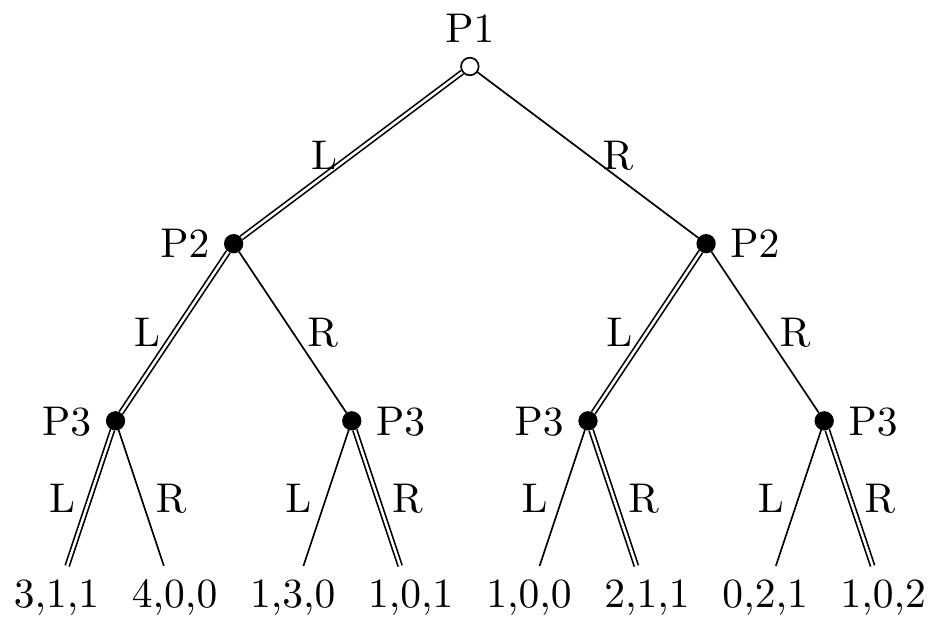

Figure 1: Tree for Q10

## Q9

So the result is Row plays D, Column plays C, and the result is Row gets 3, Column gets 6.

You just need to state the previous sentence, what’s above is working out which you can write out, but don’t have to.

## Backward Induction

10. In Figure 1, what will be the result if all players uses backward induction to solve the problem? (At each terminal node, the payouts are player 1’s, then player 2’s, then player 3’s. Each player moves once; first player 1, then player 2, then player 3.)

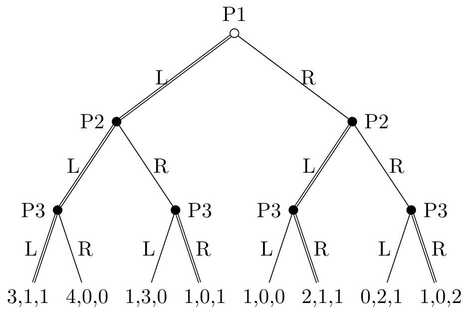

Figure 1: Tree for Q10

## Q10

Every player will move L, and the result will be that P1 gets 3, P2 gets 1, and P3 gets 1.

For exam purposes, the sentence above is all you need to say.

For working out purposes, I’ve revised the diagram for this page so that it shows (with double lines) what move each player will make at each node where they could move.

## Q11

**Answer One**

Proposer plays Left if A; Right if B.

Respond plays Up if L; Down if R.

That’s all you need to say, but to confirm it’s a correct answer, ask yourself the following four questions, all of which should get the answer **No**.

- Would Proposer do better by switching if A, in this case going from Left if A to Right if A?

**No**. Respond plays Down if R, and if Proposer is A, plays R, and Respond plays Down, they get 0. As it stands, if A they get 1, and 0 is not greater than 1.

- Would Proposer do better by switching if B, in this case going from Right if B to Left if B?

**No**. Respond plays Up if Left, and if Proposer is B, plays L, and Respond plays Up, they get 2. As it stands, if B they get 3, and 2 is not greater than 3.

- Would Respond do better by switching if L, in this case going from Up if L to Down if L?

- Would Respond do better by switching if R, in this case going from Down if R to Up if R?

**Answer Two**

Proposer plays Right if A; Left if B.

Respond plays Up no matter what.

I won’t go through the four questions, but you can check that the answer is **No** in every case.

This is still a separating equilibrium, because what matters is that *Proposer* plays different things if A or if B.

12. What is the human capital theory of the explanation of the college wage premium? Describe one objection to it. (You do not have to answer the objection.)

According to the human capital theory of the college wage premium, college students acquire skills by going to college, and those skills are economically valuable. So employers pay them more because they expect that people with these skills will provide more value (i.e., increase profits by a greater amount) than workers without those skills.

## Human Capital

12. What is the human capital theory of the explanation of the college wage premium? Describe one objection to it. (You do not have to answer the objection.)

## Q12

According to the human capital theory of the college wage premium, college students acquire skills by going to college, and those skills are economically valuable. So employers pay them more because they expect that people with these skills will provide more value (i.e., increase profits by a greater amount) than workers without those skills.

## Q12

The slides go over three objections to this:

- Hard to see causal story for some kinds of degrees
- Colleges don’t gatekeep courses
- Workers with some college background don’t get a notable wage premium.

## Other Notes

There will be a sheet provided on which to write answers. You may want to bring blank paper for working things out.

Calculators are allowed.

People who have extended time or quiet space accommodations will be in room G026, about 150 feet to your left (my right).

## Good luck!

And have a great summer, and hopefully I’ll see some of you at one or other graduation ceremony!